# Impact of weather events using storm database

KHAWLA

2023-04-20

Reproducible Research Project 2

# Synopsis

Storms and other severe weather events can cause both public health and economic problems for communities and municipalities. Many severe events can result in **fatalities**, **injuries**, and **property damage**, and preventing such outcomes to the extent possible is a key concern. This study explores the U.S. National Oceanic and Atmospheric Administration’s (NOAA) storm database. Tornadoes are wreaking havoc among the catastrophes with the most fatalities and injuries while property damage is due to floods.

# Data

The events in the database start in the year 1950 and end in November 2011.

- **DataSet**: [Storm Data](https://d396qusza40orc.cloudfront.net/repdata%2Fdata%2FStormData.csv.bz2)
- **Documentation**: [National Weather Service](https://d396qusza40orc.cloudfront.net/repdata%2Fpeer2_doc%2Fpd01016005curr.pdf)

# Data Processing

### Loading storm data

```r
file.url <- ("https://d396qusza40orc.cloudfront.net/repdata%2Fdata%2FStormData.csv.bz2")
download.file(file.url, destfile = "repdata_data_StormData.csv.bz2")
data.storm <- read.csv(bzfile("repdata_data_StormData.csv.bz2"))
```

### Data Preview

```r
str(data.storm)
```

```
## 'data.frame':    902297 obs. of  37 variables:
##  $ STATE__   : num  1 1 1 1 1 1 1 1 1 1 ...
##  $ BGN_DATE  : chr  "4/18/1950 0:00:00" "4/18/1950 0:00:00" "2/20/1951 0:00:00" "6/8/1951 0:00:00" ...
##  $ BGN_TIME  : chr  "0130" "0145" "1600" "0900" ...
##  $ TIME_ZONE : chr  "CST" "CST" "CST" "CST" ...
##  $ COUNTY    : num  97 3 57 89 43 77 9 123 125 57 ...
##  $ COUNTYNAME: chr  "MOBILE" "BALDWIN" "FAYETTE" "MADISON" ...
##  $ STATE     : chr  "AL" "AL" "AL" "AL" ...
##  $ EVTYPE    : chr  "TORNADO" "TORNADO" "TORNADO" "TORNADO" ...
##  $ BGN_RANGE : num  0 0 0 0 0 0 0 0 0 0 ...
##  $ BGN_AZI   : chr  "" "" "" "" ...
##  $ BGN_LOCATI: chr  "" "" "" "" ...
##  $ END_DATE  : chr  "" "" "" "" ...
##  $ END_TIME  : chr  "" "" "" "" ...
##  $ COUNTY_END: num  0 0 0 0 0 0 0 0 0 0 ...
```

[output cut: 23 more lines]

```r
summary(data.storm)
```

```
##     STATE__       BGN_DATE           BGN_TIME          TIME_ZONE
##  Min.   : 1.0   Length:902297      Length:902297      Length:902297
##  1st Qu.:19.0   Class :character   Class :character   Class :character
##  Median :30.0   Mode  :character   Mode  :character   Mode  :character
##  Mean   :31.2
##  3rd Qu.:45.0
##  Max.   :95.0
##
##      COUNTY       COUNTYNAME           STATE              EVTYPE
##  Min.   :  0.0   Length:902297      Length:902297      Length:902297
##  1st Qu.: 31.0   Class :character   Class :character   Class :character
##  Median : 75.0   Mode  :character   Mode  :character   Mode  :character
##  Mean   :100.6
##  3rd Qu.:131.0
##  Max.   :873.0
##
##    BGN_RANGE          BGN_AZI           BGN_LOCATI          END_DATE
##  Min.   :   0.000   Length:902297      Length:902297      Length:902297
##  1st Qu.:   0.000   Class :character   Class :character   Class :character
##  Median :   0.000   Mode  :character   Mode  :character   Mode  :character
##  Mean   :   1.484
##  3rd Qu.:   1.000
##  Max.   :3749.000
##
##    END_TIME           COUNTY_END COUNTYENDN       END_RANGE
##  Length:902297      Min.   :0    Mode:logical   Min.   :  0.0000
##  Class :character   1st Qu.:0    NA's:902297    1st Qu.:  0.0000
##  Mode  :character   Median :0                   Median :  0.0000
##                     Mean   :0                   Mean   :  0.9862
##                     3rd Qu.:0                   3rd Qu.:  0.0000
##                     Max.   :0                   Max.   :925.0000
##
##    END_AZI           END_LOCATI            LENGTH              WIDTH
##  Length:902297      Length:902297      Min.   :   0.0000   Min.   :   0.000
##  Class :character   Class :character   1st Qu.:   0.0000   1st Qu.:   0.000
##  Mode  :character   Mode  :character   Median :   0.0000   Median :   0.000
##                                        Mean   :   0.2301   Mean   :   7.503
##                                        3rd Qu.:   0.0000   3rd Qu.:   0.000
##                                        Max.   :2315.0000   Max.   :4400.000
##
```

[output cut: 25 more lines]

```
##  Min.   :-14451   Min.   :   0   Min.   :-14455   Length:902297
##  1st Qu.:  7247   1st Qu.:   0   1st Qu.:     0   Class :character
##  Median :  8707   Median :   0   Median :     0   Mode  :character
##  Mean   :  6940   Mean   :1452   Mean   :  3509
##  3rd Qu.:  9605   3rd Qu.:3549   3rd Qu.:  8735
##  Max.   : 17124   Max.   :9706   Max.   :106220
##                   NA's   :40
##      REFNUM
##  Min.   :     1
##  1st Qu.:225575
##  Median :451149
##  Mean   :451149
##  3rd Qu.:676723
##  Max.   :902297
##
```

```r
head(data.storm)
```

|  | STATE__ | BGN_DATE | BGN_TIME | TIME_ZONE | COUNTY | COUNTYNAME | STATE | EVTYPE | BGN_RANGE | BGN_AZI | BGN_LOCATI | END_DATE | END_TIME | COUNTY_END | COUNTYENDN | END_RANGE | END_AZI | END_LOCATI | LENGTH | WIDTH | F | MAG | FATALITIES | INJURIES | PROPDMG | PROPDMGEXP | CROPDMG | CROPDMGEXP | WFO | … |
| --- | --- | --- | --- | --- | --- | --- | --- | --- | --- | --- | --- | --- | --- | --- | --- | --- | --- | --- | --- | --- | --- | --- | --- | --- | --- | --- | --- | --- | --- | --- |
| 1 | 1 | 4/18/1950 0:00:00 | 0130 | CST | 97 | MOBILE | AL | TORNADO | 0 |  |  |  |  | 0 | NA | 0 |  |  | 14.0 | 100 | 3 | 0 | 0 | 15 | 25.0 | K | 0 |  |  | … |
| 2 | 1 | 4/18/1950 0:00:00 | 0145 | CST | 3 | BALDWIN | AL | TORNADO | 0 |  |  |  |  | 0 | NA | 0 |  |  | 2.0 | 150 | 2 | 0 | 0 | 0 | 2.5 | K | 0 |  |  | … |
| 3 | 1 | 2/20/1951 0:00:00 | 1600 | CST | 57 | FAYETTE | AL | TORNADO | 0 |  |  |  |  | 0 | NA | 0 |  |  | 0.1 | 123 | 2 | 0 | 0 | 2 | 25.0 | K | 0 |  |  | … |
| 4 | 1 | 6/8/1951 0:00:00 | 0900 | CST | 89 | MADISON | AL | TORNADO | 0 |  |  |  |  | 0 | NA | 0 |  |  | 0.0 | 100 | 2 | 0 | 0 | 2 | 2.5 | K | 0 |  |  | … |
| 5 | 1 | 11/15/1951 0:00:00 | 1500 | CST | 43 | CULLMAN | AL | TORNADO | 0 |  |  |  |  | 0 | NA | 0 |  |  | 0.0 | 150 | 2 | 0 | 0 | 2 | 2.5 | K | 0 |  |  | … |
| 6 | 1 | 11/15/1951 0:00:00 | 2000 | CST | 77 | LAUDERDALE | AL | TORNADO | 0 |  |  |  |  | 0 | NA | 0 |  |  | 1.5 | 177 | 2 | 0 | 0 | 6 | 2.5 | K | 0 |  |  | … |

```r
names(data.storm) <- tolower(names(data.storm))
```

The data set contains 37 variables and 902297 observations.

### Data Preparation

```r
library(dplyr)
storm <- data.storm %>%
  select(c("evtype","fatalities","injuries","propdmg","propdmgexp","cropdmg","cropdmgexp"))
head(storm)
```

|  | evtype | fatalities | injuries | propdmg | propdmgexp | cropdmg | cropdmgexp |
| --- | --- | --- | --- | --- | --- | --- | --- |
| 1 | TORNADO | 0 | 15 | 25.0 | K | 0 |  |
| 2 | TORNADO | 0 | 0 | 2.5 | K | 0 |  |
| 3 | TORNADO | 0 | 2 | 25.0 | K | 0 |  |
| 4 | TORNADO | 0 | 2 | 2.5 | K | 0 |  |
| 5 | TORNADO | 0 | 2 | 2.5 | K | 0 |  |
| 6 | TORNADO | 0 | 6 | 2.5 | K | 0 |  |

```r
summary(storm)
```

```
##     evtype            fatalities          injuries            propdmg
##  Length:902297      Min.   :  0.0000   Min.   :   0.0000   Min.   :   0.00
##  Class :character   1st Qu.:  0.0000   1st Qu.:   0.0000   1st Qu.:   0.00
##  Mode  :character   Median :  0.0000   Median :   0.0000   Median :   0.00
##                     Mean   :  0.0168   Mean   :   0.1557   Mean   :  12.06
##                     3rd Qu.:  0.0000   3rd Qu.:   0.0000   3rd Qu.:   0.50
##                     Max.   :583.0000   Max.   :1700.0000   Max.   :5000.00
##   propdmgexp           cropdmg         cropdmgexp
##  Length:902297      Min.   :  0.000   Length:902297
##  Class :character   1st Qu.:  0.000   Class :character
##  Mode  :character   Median :  0.000   Mode  :character
##                     Mean   :  1.527
##                     3rd Qu.:  0.000
##                     Max.   :990.000
```

```r
str(storm)
```

```
## 'data.frame':    902297 obs. of  7 variables:
##  $ evtype    : chr  "TORNADO" "TORNADO" "TORNADO" "TORNADO" ...
##  $ fatalities: num  0 0 0 0 0 0 0 0 1 0 ...
##  $ injuries  : num  15 0 2 2 2 6 1 0 14 0 ...
##  $ propdmg   : num  25 2.5 25 2.5 2.5 2.5 2.5 2.5 25 25 ...
##  $ propdmgexp: chr  "K" "K" "K" "K" ...
##  $ cropdmg   : num  0 0 0 0 0 0 0 0 0 0 ...
##  $ cropdmgexp: chr  "" "" "" "" ...
```

```r
View(storm)
sum(is.na(storm))
```

```
## [1] 0
```

We’ll use only 7 variables:

**evtype**: type of event

**fatalities**: number of fatalities for each event

**injuries**: number of injuries for each event

**propdmg**: property damage

**cropdmgexp**: crop damage exponents (in B, M, K and H)

```r
rm(data.storm)
```

we remove the raw data set and keep on working on the *storm* data set

### Data Cleaning

```r
sum(unique(storm$fatalities))
```

```
## [1] 2342
```

```r
sum(unique(storm$injuries))
```

```
## [1] 35453
```

```r
sum(unique(storm$propdmg))
```

```
## [1] 280155
```

```r
unique(storm$propdmgexp)
```

```
##  [1] "K" "M" ""  "B" "m" "+" "0" "5" "6" "?" "4" "2" "3" "h" "7" "H" "-" "1" "8"
```

```r
unique(storm$cropdmgexp)
```

```
## [1] ""  "M" "K" "m" "B" "?" "0" "k" "2"
```

we look for any unusual data

```r
storm$propdmgexp[storm$propdmgexp %in% c("","+","-","?")] <- "0"
storm$propdmgexp[storm$propdmgexp %in% c("B")] <- "9"
storm$propdmgexp[storm$propdmgexp %in% c("M","m")] <- "6"
storm$propdmgexp[storm$propdmgexp %in% c("K")] <- "3"
storm$propdmgexp[storm$propdmgexp %in% c("H","h")] <- "2"
```

```r
storm$cropdmgexp[storm$cropdmgexp %in% c("","?")] <- "0"
storm$cropdmgexp[storm$cropdmgexp %in% c("B")] <- "9"
storm$cropdmgexp[storm$cropdmgexp %in% c("M","m")] <- "6"
storm$cropdmgexp[storm$cropdmgexp %in% c("K","k")] <- "3"
```

```r
storm$propdmgtotal <- storm$propdmg*(10^as.numeric(storm$propdmgexp))
storm$cropdmgtotal <- storm$cropdmg*(10^as.numeric(storm$cropdmgexp))
storm$dmgtotal <- storm$propdmgtotal+ storm$cropdmgtotal
```

we found that the last two variables do not have clean data so we clean it.

```r
storm_by_event <- storm %>%
  group_by(evtype) %>%
  summarize(sum_fatalities = sum(fatalities),
            sum_injuries = sum(injuries),
            sum_propdmg = sum(propdmgtotal),
            sum_cropdmg = sum(cropdmgtotal),
            sum_totaldmg = sum(dmgtotal))
head(storm_by_event)
```

| evtype | sum_fatalities | sum_injuries | sum_propdmg | sum_cropdmg | sum_totaldmg |
| --- | --- | --- | --- | --- | --- |
| HIGH SURF ADVISORY | 0 | 0 | 200000 | 0 | 200000 |
| COASTAL FLOOD | 0 | 0 | 0 | 0 | 0 |
| FLASH FLOOD | 0 | 0 | 50000 | 0 | 50000 |
| LIGHTNING | 0 | 0 | 0 | 0 | 0 |
| TSTM WIND | 0 | 0 | 8100000 | 0 | 8100000 |
| TSTM WIND (G45) | 0 | 0 | 8000 | 0 | 8000 |

we summarized the data by events showing each event with its summarized fatalities, injuries and damages.

1. Across the United States, which types of events (as indicated in the **EVTYPE** variable) are most harmful with respect to population health?

```r
# Events that caused most fatalities
storm_fatalities <- arrange(storm_by_event, desc(sum_fatalities))
fatalitydata <- head(storm_fatalities)
fatalitydata
```

| evtype | sum_fatalities | sum_injuries | sum_propdmg | sum_cropdmg | sum_totaldmg |
| --- | --- | --- | --- | --- | --- |
| TORNADO | 5633 | 91346 | 56947380677 | 414953270 | 57362333947 |
| EXCESSIVE HEAT | 1903 | 6525 | 7753700 | 492402000 | 500155700 |
| FLASH FLOOD | 978 | 1777 | 16822673979 | 1421317100 | 18243991079 |
| HEAT | 937 | 2100 | 1797000 | 401461500 | 403258500 |
| LIGHTNING | 816 | 5230 | 930379430 | 12092090 | 942471520 |
| TSTM WIND | 504 | 6957 | 4484928495 | 554007350 | 5038935845 |

```r
# Events that caused most injuries
storm_injuries <- arrange(storm_by_event, desc(sum_injuries))
injurydata <- head(storm_injuries)
injurydata
```

| evtype | sum_fatalities | sum_injuries | sum_propdmg | sum_cropdmg | sum_totaldmg |
| --- | --- | --- | --- | --- | --- |
| TORNADO | 5633 | 91346 | 56947380677 | 414953270 | 57362333947 |
| TSTM WIND | 504 | 6957 | 4484928495 | 554007350 | 5038935845 |
| FLOOD | 470 | 6789 | 144657709807 | 5661968450 | 150319678257 |
| EXCESSIVE HEAT | 1903 | 6525 | 7753700 | 492402000 | 500155700 |
| LIGHTNING | 816 | 5230 | 930379430 | 12092090 | 942471520 |
| HEAT | 937 | 2100 | 1797000 | 401461500 | 403258500 |

we retain only the first 6 events that caused the most fatalities and injuries.

2. Across the United States, which types of events have the greatest economic consequences?

```r
# Events with greatest economic consequences
storm_damage <- arrange(storm_by_event, desc(sum_totaldmg))
damagedata <- head(storm_damage)
damagedata
```

| evtype | sum_fatalities | sum_injuries | sum_propdmg | sum_cropdmg | sum_totaldmg |
| --- | --- | --- | --- | --- | --- |
| FLOOD | 470 | 6789 | 144657709807 | 5661968450 | 150319678257 |
| HURRICANE/TYPHOON | 64 | 1275 | 69305840000 | 2607872800 | 71913712800 |
| TORNADO | 5633 | 91346 | 56947380677 | 414953270 | 57362333947 |
| STORM SURGE | 13 | 38 | 43323536000 | 5000 | 43323541000 |
| HAIL | 15 | 1361 | 15735267513 | 3025954473 | 18761221986 |
| FLASH FLOOD | 978 | 1777 | 16822673979 | 1421317100 | 18243991079 |

we retain only the first 6 events that caused the most economic consequences.

# Results

```r
library(ggplot2)
```

**FATALITIES**

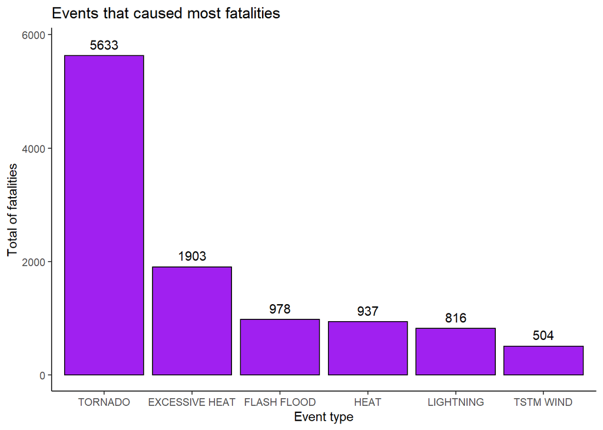

```r
ggplot(fatalitydata, aes(reorder(evtype, -sum_fatalities),sum_fatalities))+
  geom_bar(stat = "identity",color= "black", fill="purple")+
  geom_text(aes(label = sum_fatalities), nudge_y = 200)+
  ggtitle("Events that caused most fatalities")+
  xlab("Event type") + ylab("Total of fatalities") +
  theme_classic()
```

**INJURIES**

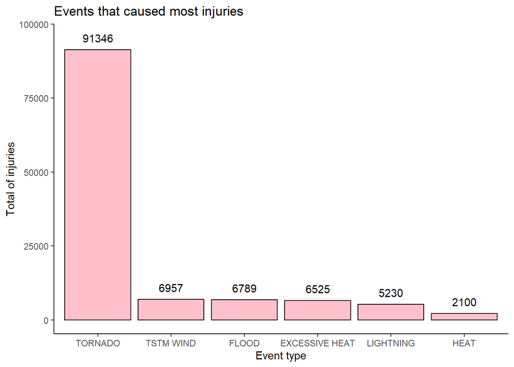

```r
ggplot(injurydata, aes(reorder(evtype, -sum_injuries),sum_injuries))+
  geom_bar(stat = "identity",color= "black", fill="pink")+
  geom_text(aes(label = sum_injuries), nudge_y = 4000)+
  ggtitle("Events that caused most injuries")+
  xlab("Event type") + ylab("Total of injuries") +
  theme_classic()
```

it looks like **Tornadoes** causes the most injuries with 91346 and exceeds by far **TSTM Wind** which registered 6957 injuries.

**ECONOMIC CONSEQUENCES/DAMAGES**

```r
library(tidyverse)
head(damagedata)
```

| evtype | sum_fatalities | sum_injuries | sum_propdmg | sum_cropdmg | sum_totaldmg |
| --- | --- | --- | --- | --- | --- |
| FLOOD | 470 | 6789 | 144657709807 | 5661968450 | 150319678257 |
| HURRICANE/TYPHOON | 64 | 1275 | 69305840000 | 2607872800 | 71913712800 |
| TORNADO | 5633 | 91346 | 56947380677 | 414953270 | 57362333947 |
| STORM SURGE | 13 | 38 | 43323536000 | 5000 | 43323541000 |
| HAIL | 15 | 1361 | 15735267513 | 3025954473 | 18761221986 |
| FLASH FLOOD | 978 | 1777 | 16822673979 | 1421317100 | 18243991079 |

```r
damage <- damagedata %>%
  gather(key = "Type", value = "TotalDamage",c("sum_propdmg","sum_cropdmg")) %>%
  select(evtype, Type, TotalDamage)

damage
```

| evtype | Type | TotalDamage |
| --- | --- | --- |
| FLOOD | sum_propdmg | 144657709807 |
| HURRICANE/TYPHOON | sum_propdmg | 69305840000 |
| TORNADO | sum_propdmg | 56947380677 |
| STORM SURGE | sum_propdmg | 43323536000 |
| HAIL | sum_propdmg | 15735267513 |
| FLASH FLOOD | sum_propdmg | 16822673979 |
| FLOOD | sum_cropdmg | 5661968450 |
| HURRICANE/TYPHOON | sum_cropdmg | 2607872800 |
| TORNADO | sum_cropdmg | 414953270 |
| STORM SURGE | sum_cropdmg | 5000 |

[output cut: 2 more lines]

```r
damage$Type[damage$Type %in% c("sum_propdmg")] <- "property damage"
damage$Type[damage$Type %in% c("sum_cropdmg")] <- "crop damage"
damage
```

| evtype | Type | TotalDamage |
| --- | --- | --- |
| FLOOD | property damage | 144657709807 |
| HURRICANE/TYPHOON | property damage | 69305840000 |
| TORNADO | property damage | 56947380677 |
| STORM SURGE | property damage | 43323536000 |
| HAIL | property damage | 15735267513 |
| FLASH FLOOD | property damage | 16822673979 |
| FLOOD | crop damage | 5661968450 |
| HURRICANE/TYPHOON | crop damage | 2607872800 |
| TORNADO | crop damage | 414953270 |
| STORM SURGE | crop damage | 5000 |

[output cut: 2 more lines]

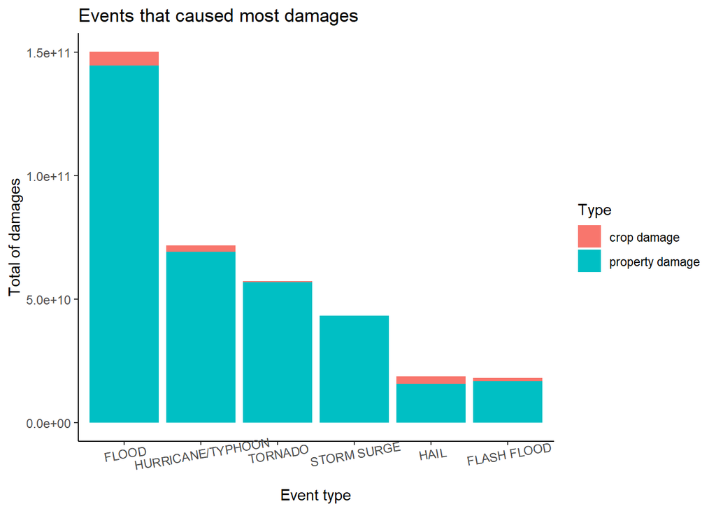

```r
damage$evtype <- with(data = damage, reorder(evtype, -TotalDamage))

ggplot(damage, aes(x = evtype, y = TotalDamage, fill = Type))+
  geom_bar(position = "stack" , stat = "identity")+
  ggtitle("Events that caused most damages")+
  xlab("Event type") + ylab("Total of damages") +
  theme_classic()+ theme(axis.text.x = element_text(angle = 10))
```

it looks like **Floods** cause the most damage in terms of crop and property damages followed by **Hurricanes** and **Tornadoes**